| title: "BDA - Assignment 7" |
| --- |
| author: "Anonymous" |
| output: |
| pdf_document: |
| toc: yes |
| toc_depth: 1 |

```r
# To install aaltobda, see the General information in the assignment.
library(aaltobda)
library("ggplot2")
library(rstan)
```

# 1. Linear model: drowning data with Stan (3p)

The provided data drowning in the aaltobda package contains the number of people who died from drowning each year in Finland 1980–2019. A statistician is going to fit a linear model with Gaussian residual model to these data using time as the predictor and number of drownings as the target variable (see the related linear model example for the Kilpisj¨arvi-temperature data in the example Stan codes). She has two objective questions:

1. What is the trend of the number of people drowning per year? We would plot the histogram of the slope of the linear model.
2. What is the prediction for the year 2020? We would plot the histogram of the posterior predictive distribution for the number of people drowning at ˜x = 2020.

Your task is to fix the Stan code to be able to run this linear regression model.

The data for the assignment.

```r
data("drowning")
```

## 1.

The three mistakes in the code and how I fixed them:

1. The fist mistake was that there was no semi-colon at the end of the row where the model was defined. Fix: Added the the semi-colon.
2. The standard deviatoin parameter sigma had upper bound set. There should not be a upper bound for this parameter. Only contraint is that it cannot be negative. Fix: Change upper bound constraint to lower bound constraint.
3. The quantity ypred is a real number drawn from a normal distribution. There was mu as a parameter for the normal distribution in the initial code. This caused error, because mu is a vector of dimension N. Fix: For ypred, we need to use xpred when transforming parameter mupred. This way, we get real number mupred, which we can give as a parameter to normal distribution where the ypred is to be sampled from.

## 2.

Determining suitable value for $\sigma_{\beta}$. The approximate numerical value for $\sigma_{\beta}$ is

```r
bound <- 69
sigma_quantile <- qnorm(c(0.005, 0.995))
sb <- bound / sigma_quantile
sb[2]
```

```
## [1] 26.78749
```

## 3.

Adding the desired beta prior in the Stan code:

Added line ...

real sigma_beta ;

Added line ...

beta ~ normal (0, sigma_beta) ; // Weakly informative prior for beta added here.

... in model block.

## 4.

Adding the weakly informative prior for the intercept alpha.

If we approach the problem of determining weakly informative alpha (normal) prior in a similar manner as was done in the part 2 for beta prior, we need to figure out the crude estimates, between which two values the intercept lies with high probability. We can use, for example the same probability of 0.99 that used in part 2.

I added a hand-made plot which visualizes the bounds for intercept alpha.

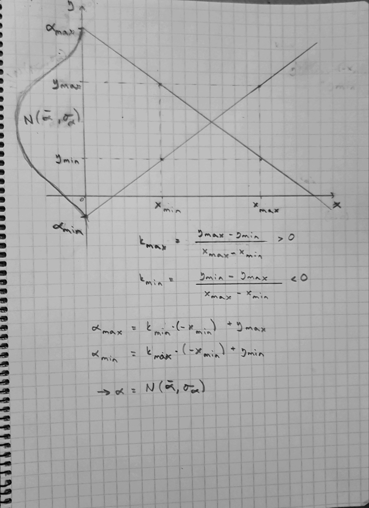

```r
knitr::include_graphics("BDA_7.jpg")
```

So basically, the boundaries for the alpha intercept can be approximated by setting two lines that have the max and min slope coefficients based on the data. With 0.99 probabilty, we can say that the intercept for our model is something betweeen the boundaries. Based on this weak information about the intercept boundaries, we can compute the required parameters for our normal weakly informative prior form where alpha can be sampled.

Now we need to implement the calculations in R, based on the plot/sketch above. The approximate numerical value for $\mu_{\alpha}$ is

```r
# Calculate the min and max values for both x and y
y_min <- min(drowning$drownings)
y_max <- max(drowning$drownings)
x_min <- min(drowning$year)
x_max <- max(drowning$year)

# Decide the maximum and minimum slope coefficient
k_max <- (y_max - y_min) / (x_max - x_min)
k_min <- (y_min - y_max) / (x_max - x_min)

# Compute maximum and minimum values for intercept bound where we assume the intercept to lie with 0.99 probability.
alpha_min = k_max * (-x_min) + y_min
alpha_max = k_min * (-x_min) + y_max

# Prior of alpha is normal distribution, so we need to compute mu_alpha.
# It is the mean of the boundary values.
ma <- mean(c(alpha_min, alpha_max))
ma
```

```
## [1] 143
```

The approximate numerical value for $\sigma_{\alpha}$ is

```r
# Bound is decided with taking the difference between the mean of the normal distribution and the minimum boundary value.
bound <- ma - alpha_min
# Now we calculate the sigma_alpha similarly as we calculated sigma_beta in part b.
sigma_quantile <- qnorm(c(0.005, 0.995))
sa <- bound / sigma_quantile
sa[2]
```

```
## [1] 2456.296
```

Adding the desired alpha prior in the Stan code:

Added lines ...

real sigma_alpha ; real mu_alpha ;

Added line ...

alpha ~ normal (mu_alpha, sigma_alpha) ; // Weakly informative prior for alpha added here.

... in model block.

Add all the necessary data into one list.

```r
drowning_data <- list(N = dim(drowning)[1], x = drowning$year, y = drowning$drownings, xpred = 2020, sigma_alpha = sa[2], mu_alpha = ma, sigma_beta = sb[2])
```

THE STAN MODEL:

```stan
data {
  int <lower =0 > N; // number of data points
  vector [N] x ; // observation year
  vector [N] y ; // observation number of drowned
  real xpred ; // prediction year
  real sigma_alpha ;
  real mu_alpha ;
  real sigma_beta ;
}
parameters {
  real alpha ;
  real beta ;
  real <lower = 0> sigma ; // Mistake 2. The upper bound changed to lower bound.
}
transformed parameters {
  vector [N] mu = alpha + beta * x ;
  real mupred = alpha + beta *  xpred ; // Mistake 3. Set parameter mupred.
}
model {
  alpha ~ normal (mu_alpha, sigma_alpha) ; // Weakly informative prior for alpha added here.
  beta ~ normal (0, sigma_beta) ; // Weakly informative prior for beta added here.
  y ~ normal (mu , sigma) ; // Mistake 1. There was no semi-colon here.
}
generated quantities {
  real ypred = normal_rng (mupred, sigma); // Mistake 3. Use mupred instead of mu.
}
```

```r
fit <- sampling(drowning_model, drowning_data, seed = 123, refresh=0)
monitor(fit, print = FALSE)[c(1, 2, 3, 42), c(1, 3, 10)]
```

[output not shown]

So, the answers for the two objective question are...

1. The trend of the number of people dying each year is negative, so each year less people are drowning.
2. Prediction for the year 2020 is 122 if rounded upwards.

# 2. Hierarchical model: factory data with Stan (3p)

The factory data in the aaltobda package contains quality control measurements from 6 machines in a factory (units of the measurements are irrelevant here). In the data file, each column contains the measurements for a single machine. Quality control measurements are expensive and time-consuming, so only 5 measurements were done for each machine. In addition to the existing machines, we are interested in the quality of another machine (the seventh machine.

```r
library(aaltobda)
data("factory")
```

## Separate model

In the Stan github page (https://github.com/stan-dev/stan/wiki/Prior-Choice-Recommendations) it says that a good general weakly informative prior is normal distribution with mean equal to data mean and standrad deviation equal to deviation between the column means:

```r
prior_mu <- mean(colMeans(factory))
prior_sigma <- sd(colMeans(factory))

prior_mu
```

```
## [1] 92.93333
```

```r
prior_sigma
```

```
## [1] 13.37321
```

```stan
data {
  int < lower =0 > N; // n of measurements
  int < lower =0 > J; // n of machines
  vector[J] y[N];
}
parameters {
  vector[J] mu ;
  vector<lower = 0>[J] sigma ;
}
model {
  // weakly informative priors
  for ( j in 1: J ){
    mu [j] ~ normal (92.93, 13.37);
    sigma [j] ~ inv_chi_square (10);
  }
  // likelihood
  for ( j in 1: J )
    y[ ,j ] ~ normal (mu[j], sigma[j]);
}
generated quantities {
  vector[J] ypred ;
  // Compute predictive distribution for J machines
  for (j in 1:J)
    ypred[j] = normal_rng (mu[j], sigma[j]);
}
```

```r
stan_data <- list(y = factory,N = nrow(factory),J = ncol(factory))
model <- rstan::sampling(separate_model, data = stan_data)
model
```

```
## Inference for Stan model: 853880db5a5fa339fa9c543b5adc15ea.
## 4 chains, each with iter=2000; warmup=1000; thin=1;
## post-warmup draws per chain=1000, total post-warmup draws=4000.
##
##             mean se_mean    sd    2.5%     25%     50%     75%   97.5% n_eff
## mu[1]      79.33    0.10  6.12   68.15   75.37   79.08   82.91   92.12  3955
## mu[2]     105.14    0.05  3.71   97.45  102.86  105.19  107.57  112.15  4647
## mu[3]      88.29    0.06  4.04   80.24   85.67   88.34   90.83   96.30  4575
## mu[4]     110.89    0.04  2.53  105.78  109.39  110.97  112.45  115.86  4248
## mu[5]      90.19    0.06  3.42   83.16   88.08   90.16   92.24   97.11  3545
## mu[6]      87.33    0.08  5.61   76.55   83.76   87.09   90.80   98.99  5203
## sigma[1]   14.45    0.06  3.89    9.10   11.73   13.67   16.32   24.02  3760
## sigma[2]    8.61    0.04  2.26    5.42    7.05    8.23    9.73   14.12  3606
## sigma[3]    9.29    0.04  2.47    5.93    7.58    8.84   10.47   15.43  3184
## sigma[4]    5.55    0.03  1.53    3.49    4.52    5.25    6.23    9.40  2797
## sigma[5]    7.83    0.04  2.08    4.99    6.37    7.49    8.86   12.95  3350
## sigma[6]   13.91    0.05  3.68    8.79   11.38   13.29   15.72   22.51  4850
## ypred[1]   79.19    0.26 16.16   48.02   68.87   78.92   89.32  111.66  3830
## ypred[2]  105.26    0.15  9.58   86.02   99.20  105.38  111.45  124.27  4103
## ypred[3]   88.20    0.18 10.53   67.81   81.42   88.28   94.89  109.12  3602
## ypred[4]  111.08    0.10  6.40   98.33  107.20  111.07  115.05  123.85  3791
## ypred[5]   90.13    0.14  8.91   72.53   84.65   90.09   95.56  108.23  4008
## ypred[6]   87.11    0.24 15.50   56.48   77.15   87.16   96.67  118.35  4193
## lp__     -165.13    0.07  2.55 -170.86 -166.68 -164.79 -163.25 -161.15  1480
##          Rhat
## mu[1]       1
## mu[2]       1
## mu[3]       1
## mu[4]       1
## mu[5]       1
## mu[6]       1
## sigma[1]    1
## sigma[2]    1
## sigma[3]    1
## sigma[4]    1
## sigma[5]    1
## sigma[6]    1
## ypred[1]    1
## ypred[2]    1
## ypred[3]    1
## ypred[4]    1
## ypred[5]    1
## ypred[6]    1
## lp__        1
##
## Samples were drawn using NUTS(diag_e) at Fri Oct 30 15:53:18 2020.
## For each parameter, n_eff is a crude measure of effective sample size,
## and Rhat is the potential scale reduction factor on split chains (at
## convergence, Rhat=1).
```

Plot the histograms:

### i) the posterior distribution of the mean of the quality measurements of the sixth machine.

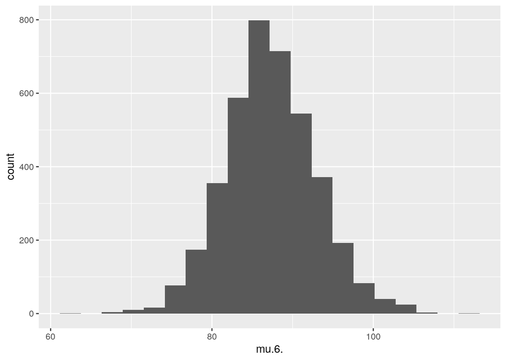

```r
draws <- as.data.frame(extract(model, pars = c("mu[6]", "ypred[6]"), permuted = T))
hist1 <- ggplot(draws, aes(mu.6.)) + geom_histogram(bins=20)
hist1
```

### ii) the predictive distribution for another quality measurement of the sixth machine.

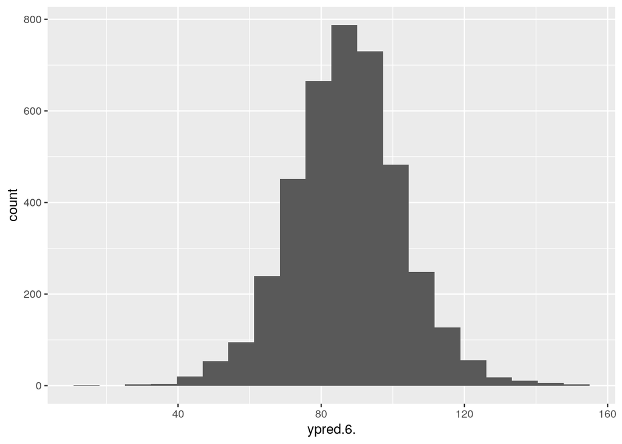

```r
hist2 <- ggplot(draws, aes(ypred.6.)) + geom_histogram(bins=20)
hist2
```

### iii) the posterior distribution of the mean of the quality measurements of the seventh machine.

We cannot plot a histogram of the posteror distribution for the seventh machine, as we are modeling each machine separately and cannot say anything about seventh machine based on these models.

### Separate model described with mathematical notation

$$y_{ij} \sim N(\mu_j, \sigma_j)$$
$$\mu_j \sim N(\bar{y}, \bar{\sigma_i})$$
$$\sigma_j = Inv-\chi^2(10)$$

## Pooled model

```r
prior_mu <- mean(unlist(factory))
prior_sigma <- sd(unlist(factory))

prior_mu
```

```
## [1] 92.93333
```

```r
prior_sigma
```

```
## [1] 18.00179
```